# Optimal Treatment Analysis

## Outcome Variable

**Outcome Variable:** ever_stunted

## Predictor Variables

**Intervention Variable:** gagebrth

**Adjustment Set:**

- arm
- sex
- W_mage
- meducyrs
- feducyrs
- hhwealth_quart
- W_nrooms
- W_nchldlt5
- brthmon
- W_parity
- impsan
- delta_W_mage
- delta_meducyrs
- delta_feducyrs
- delta_hhwealth_quart
- delta_W_nrooms
- delta_W_nchldlt5
- delta_brthmon
- delta_W_parity
- delta_impsan

## Stratifying Variables

The analysis was stratified on these variable(s):

- agecat
- studyid
- country

## Data Summary

| agecat | studyid | country | gagebrth | ever_stunted | n_cell | n |
| --- | --- | --- | --- | --- | --- | --- |
| 0-24 months (no birth st.) | ki1000108-CMC-V-BCS-2002 | INDIA | Full or late term | 0 | 18 | 278 |
| 0-24 months (no birth st.) | ki1000108-CMC-V-BCS-2002 | INDIA | Full or late term | 1 | 164 | 278 |
| 0-24 months (no birth st.) | ki1000108-CMC-V-BCS-2002 | INDIA | Preterm | 0 | 3 | 278 |
| 0-24 months (no birth st.) | ki1000108-CMC-V-BCS-2002 | INDIA | Preterm | 1 | 30 | 278 |
| 0-24 months (no birth st.) | ki1000108-CMC-V-BCS-2002 | INDIA | Early term | 0 | 7 | 278 |
| 0-24 months (no birth st.) | ki1000108-CMC-V-BCS-2002 | INDIA | Early term | 1 | 56 | 278 |
| 0-24 months (no birth st.) | ki1000108-IRC | INDIA | Full or late term | 0 | 95 | 341 |
| 0-24 months (no birth st.) | ki1000108-IRC | INDIA | Full or late term | 1 | 126 | 341 |
| 0-24 months (no birth st.) | ki1000108-IRC | INDIA | Preterm | 0 | 9 | 341 |
| 0-24 months (no birth st.) | ki1000108-IRC | INDIA | Preterm | 1 | 23 | 341 |
| 0-24 months (no birth st.) | ki1000108-IRC | INDIA | Early term | 0 | 34 | 341 |
| 0-24 months (no birth st.) | ki1000108-IRC | INDIA | Early term | 1 | 54 | 341 |
| 0-24 months (no birth st.) | ki1000109-EE | PAKISTAN | Full or late term | 0 | 6 | 498 |
| 0-24 months (no birth st.) | ki1000109-EE | PAKISTAN | Full or late term | 1 | 30 | 498 |
| 0-24 months (no birth st.) | ki1000109-EE | PAKISTAN | Preterm | 0 | 28 | 498 |
| 0-24 months (no birth st.) | ki1000109-EE | PAKISTAN | Preterm | 1 | 292 | 498 |
| 0-24 months (no birth st.) | ki1000109-EE | PAKISTAN | Early term | 0 | 32 | 498 |
| 0-24 months (no birth st.) | ki1000109-EE | PAKISTAN | Early term | 1 | 110 | 498 |
| 0-24 months (no birth st.) | ki1000304b-SAS-CompFeed | INDIA | Full or late term | 0 | 8 | 1081 |
| 0-24 months (no birth st.) | ki1000304b-SAS-CompFeed | INDIA | Full or late term | 1 | 16 | 1081 |
| 0-24 months (no birth st.) | ki1000304b-SAS-CompFeed | INDIA | Preterm | 0 | 422 | 1081 |
| 0-24 months (no birth st.) | ki1000304b-SAS-CompFeed | INDIA | Preterm | 1 | 550 | 1081 |
| 0-24 months (no birth st.) | ki1000304b-SAS-CompFeed | INDIA | Early term | 0 | 35 | 1081 |
| 0-24 months (no birth st.) | ki1000304b-SAS-CompFeed | INDIA | Early term | 1 | 50 | 1081 |
| 0-24 months (no birth st.) | ki1017093c-NIH-Crypto | BANGLADESH | Full or late term | 0 | 105 | 653 |
| 0-24 months (no birth st.) | ki1017093c-NIH-Crypto | BANGLADESH | Full or late term | 1 | 51 | 653 |
| 0-24 months (no birth st.) | ki1017093c-NIH-Crypto | BANGLADESH | Preterm | 0 | 110 | 653 |
| 0-24 months (no birth st.) | ki1017093c-NIH-Crypto | BANGLADESH | Preterm | 1 | 89 | 653 |
| 0-24 months (no birth st.) | ki1017093c-NIH-Crypto | BANGLADESH | Early term | 0 | 181 | 653 |
| 0-24 months (no birth st.) | ki1017093c-NIH-Crypto | BANGLADESH | Early term | 1 | 117 | 653 |

[output cut: 186 more lines]

The following strata were considered:

- agecat: 0-24 months (no birth st.), studyid: ki1000108-CMC-V-BCS-2002, country: INDIA
- agecat: 0-24 months (no birth st.), studyid: ki1000108-IRC, country: INDIA
- agecat: 0-24 months (no birth st.), studyid: ki1000109-EE, country: PAKISTAN
- agecat: 0-24 months (no birth st.), studyid: ki1000304b-SAS-CompFeed, country: INDIA
- agecat: 0-24 months (no birth st.), studyid: ki1017093c-NIH-Crypto, country: BANGLADESH
- agecat: 0-24 months (no birth st.), studyid: ki1066203-TanzaniaChild2, country: TANZANIA, UNITED REPUBLIC OF
- agecat: 0-24 months (no birth st.), studyid: ki1101329-Keneba, country: GAMBIA
- agecat: 0-24 months (no birth st.), studyid: ki1119695-PROBIT, country: BELARUS
- agecat: 0-24 months (no birth st.), studyid: ki1135781-COHORTS, country: GUATEMALA
- agecat: 0-24 months (no birth st.), studyid: ki1135781-COHORTS, country: INDIA
- agecat: 0-24 months (no birth st.), studyid: ki1135781-COHORTS, country: PHILIPPINES
- agecat: 0-24 months (no birth st.), studyid: kiGH5241-JiVitA-3, country: BANGLADESH
- agecat: 0-6 months (no birth st.), studyid: ki1000108-CMC-V-BCS-2002, country: INDIA
- agecat: 0-6 months (no birth st.), studyid: ki1000108-IRC, country: INDIA
- agecat: 0-6 months (no birth st.), studyid: ki1000109-EE, country: PAKISTAN
- agecat: 0-6 months (no birth st.), studyid: ki1000304b-SAS-CompFeed, country: INDIA
- agecat: 0-6 months (no birth st.), studyid: ki1017093c-NIH-Crypto, country: BANGLADESH
- agecat: 0-6 months (no birth st.), studyid: ki1066203-TanzaniaChild2, country: TANZANIA, UNITED REPUBLIC OF
- agecat: 0-6 months (no birth st.), studyid: ki1101329-Keneba, country: GAMBIA
- agecat: 0-6 months (no birth st.), studyid: ki1119695-PROBIT, country: BELARUS
- agecat: 0-6 months (no birth st.), studyid: ki1135781-COHORTS, country: GUATEMALA
- agecat: 0-6 months (no birth st.), studyid: ki1135781-COHORTS, country: INDIA
- agecat: 0-6 months (no birth st.), studyid: ki1135781-COHORTS, country: PHILIPPINES
- agecat: 0-6 months (no birth st.), studyid: kiGH5241-JiVitA-3, country: BANGLADESH
- agecat: 6-24 months, studyid: ki1000108-CMC-V-BCS-2002, country: INDIA
- agecat: 6-24 months, studyid: ki1000108-IRC, country: INDIA
- agecat: 6-24 months, studyid: ki1000109-EE, country: PAKISTAN
- agecat: 6-24 months, studyid: ki1000304b-SAS-CompFeed, country: INDIA
- agecat: 6-24 months, studyid: ki1017093c-NIH-Crypto, country: BANGLADESH
- agecat: 6-24 months, studyid: ki1066203-TanzaniaChild2, country: TANZANIA, UNITED REPUBLIC OF
- agecat: 6-24 months, studyid: ki1101329-Keneba, country: GAMBIA
- agecat: 6-24 months, studyid: ki1119695-PROBIT, country: BELARUS
- agecat: 6-24 months, studyid: ki1135781-COHORTS, country: GUATEMALA
- agecat: 6-24 months, studyid: ki1135781-COHORTS, country: INDIA
- agecat: 6-24 months, studyid: ki1135781-COHORTS, country: PHILIPPINES
- agecat: 6-24 months, studyid: kiGH5241-JiVitA-3, country: BANGLADESH

### Dropped Strata

Some strata were dropped due to rare outcomes:

- agecat: 0-24 months (no birth st.), studyid: ki1000108-CMC-V-BCS-2002, country: INDIA
- agecat: 0-6 months (no birth st.), studyid: ki1000304b-SAS-CompFeed, country: INDIA
- agecat: 6-24 months, studyid: ki1000108-CMC-V-BCS-2002, country: INDIA

## Methods Detail

We’re interested in the causal parameters $E[Y_a]$ for all values of $a \in \mathcal{A}$. These parameters represent the mean outcome if, possibly contrary to fact, we intervened to set all units to have $A=a$. Under the randomization and positivity assumptions, these are identified by the statistical parameters $\psi_a=E_W[E_{Y|A,W}(Y|A=a,W)]$. In addition, we’re interested in the mean of $Y$, $E[Y]$ under no intervention (the observed mean). We will estimate these parameters by using SuperLearner to fit the relevant likelihood factors – $E_{Y|A,W}(Y|A=a,W)$ and $p(A=a|W)$, and then updating our likelihood fit using a joint TMLE.

For unadjusted analyses ($W=\{\}$), initial likelihoods were estimated using Lrnr_glm to estimate the simple $E(Y|A)$ and Lrnr_mean to estimate $p(A)$. For adjusted analyses, a small library containing Lrnr_glmnet, Lrnr_xgboost, and Lrnr_mean was used.

# Results Detail

## Results Plots

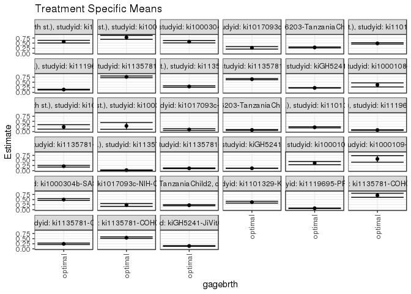

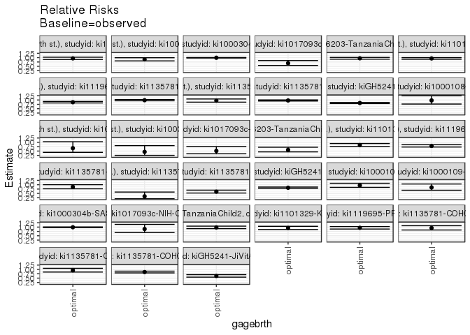

## Results Table

### Parameter: TSM

| agecat | studyid | country | intervention_level | baseline_level | estimate | ci_lower | ci_upper |
| --- | --- | --- | --- | --- | --- | --- | --- |
| 0-24 months (no birth st.) | ki1000108-IRC | INDIA | optimal | NA | 0.5699311 | 0.5045663 | 0.6352960 |
| 0-24 months (no birth st.) | ki1000109-EE | PAKISTAN | optimal | NA | 0.7807879 | 0.6833990 | 0.8781767 |
| 0-24 months (no birth st.) | ki1000304b-SAS-CompFeed | INDIA | optimal | NA | 0.5661784 | 0.5096384 | 0.6227184 |
| 0-24 months (no birth st.) | ki1017093c-NIH-Crypto | BANGLADESH | optimal | NA | 0.2679010 | 0.2054902 | 0.3303117 |
| 0-24 months (no birth st.) | ki1066203-TanzaniaChild2 | TANZANIA, UNITED REPUBLIC OF | optimal | NA | 0.2869940 | 0.2627599 | 0.3112282 |
| 0-24 months (no birth st.) | ki1101329-Keneba | GAMBIA | optimal | NA | 0.4857597 | 0.4516021 | 0.5199172 |
| 0-24 months (no birth st.) | ki1119695-PROBIT | BELARUS | optimal | NA | 0.1383923 | 0.1184658 | 0.1583189 |
| 0-24 months (no birth st.) | ki1135781-COHORTS | GUATEMALA | optimal | NA | 0.7631483 | 0.7213306 | 0.8049660 |
| 0-24 months (no birth st.) | ki1135781-COHORTS | INDIA | optimal | NA | 0.2893609 | 0.2526236 | 0.3260982 |
| 0-24 months (no birth st.) | ki1135781-COHORTS | PHILIPPINES | optimal | NA | 0.6474789 | 0.6201848 | 0.6747731 |
| 0-24 months (no birth st.) | kiGH5241-JiVitA-3 | BANGLADESH | optimal | NA | 0.2230185 | 0.2110188 | 0.2350182 |
| 0-6 months (no birth st.) | ki1000108-CMC-V-BCS-2002 | INDIA | optimal | NA | 0.3669350 | 0.2679104 | 0.4659597 |
| 0-6 months (no birth st.) | ki1000108-IRC | INDIA | optimal | NA | 0.2266758 | 0.1180195 | 0.3353321 |
| 0-6 months (no birth st.) | ki1000109-EE | PAKISTAN | optimal | NA | 0.2741949 | 0.1090736 | 0.4393162 |
| 0-6 months (no birth st.) | ki1017093c-NIH-Crypto | BANGLADESH | optimal | NA | 0.0969439 | 0.0549502 | 0.1389376 |
| 0-6 months (no birth st.) | ki1066203-TanzaniaChild2 | TANZANIA, UNITED REPUBLIC OF | optimal | NA | 0.0769549 | 0.0568073 | 0.0971025 |
| 0-6 months (no birth st.) | ki1101329-Keneba | GAMBIA | optimal | NA | 0.2084509 | 0.1797752 | 0.2371266 |
| 0-6 months (no birth st.) | ki1119695-PROBIT | BELARUS | optimal | NA | 0.0723307 | 0.0585671 | 0.0860943 |
| 0-6 months (no birth st.) | ki1135781-COHORTS | GUATEMALA | optimal | NA | 0.2172828 | 0.1757128 | 0.2588529 |
| 0-6 months (no birth st.) | ki1135781-COHORTS | INDIA | optimal | NA | 0.0231639 | 0.0094804 | 0.0368475 |
| 0-6 months (no birth st.) | ki1135781-COHORTS | PHILIPPINES | optimal | NA | 0.1140590 | 0.0958067 | 0.1323113 |
| 0-6 months (no birth st.) | kiGH5241-JiVitA-3 | BANGLADESH | optimal | NA | 0.1178244 | 0.1096978 | 0.1259510 |
| 6-24 months | ki1000108-IRC | INDIA | optimal | NA | 0.3710712 | 0.2938554 | 0.4482869 |
| 6-24 months | ki1000109-EE | PAKISTAN | optimal | NA | 0.5724404 | 0.4146367 | 0.7302441 |
| 6-24 months | ki1000304b-SAS-CompFeed | INDIA | optimal | NA | 0.4995670 | 0.4556483 | 0.5434858 |
| 6-24 months | ki1017093c-NIH-Crypto | BANGLADESH | optimal | NA | 0.2339146 | 0.1638706 | 0.3039585 |
| 6-24 months | ki1066203-TanzaniaChild2 | TANZANIA, UNITED REPUBLIC OF | optimal | NA | 0.2226144 | 0.1963723 | 0.2488564 |
| 6-24 months | ki1101329-Keneba | GAMBIA | optimal | NA | 0.3710121 | 0.3259230 | 0.4161013 |
| 6-24 months | ki1119695-PROBIT | BELARUS | optimal | NA | 0.0726458 | 0.0594842 | 0.0858075 |
| 6-24 months | ki1135781-COHORTS | GUATEMALA | optimal | NA | 0.7095034 | 0.6098259 | 0.8091808 |
| 6-24 months | ki1135781-COHORTS | INDIA | optimal | NA | 0.2466606 | 0.2095254 | 0.2837958 |
| 6-24 months | ki1135781-COHORTS | PHILIPPINES | optimal | NA | 0.5471272 | 0.5081640 | 0.5860904 |
| 6-24 months | kiGH5241-JiVitA-3 | BANGLADESH | optimal | NA | 0.1416563 | 0.1234634 | 0.1598491 |

### Parameter: E(Y)

| agecat | studyid | country | intervention_level | baseline_level | estimate | ci_lower | ci_upper |
| --- | --- | --- | --- | --- | --- | --- | --- |
| 0-24 months (no birth st.) | ki1000108-IRC | INDIA | observed | NA | 0.5948594 | 0.5426869 | 0.6470320 |
| 0-24 months (no birth st.) | ki1000109-EE | PAKISTAN | observed | NA | 0.8682431 | 0.8260437 | 0.9104426 |
| 0-24 months (no birth st.) | ki1000304b-SAS-CompFeed | INDIA | observed | NA | 0.5701321 | 0.5150155 | 0.6252487 |
| 0-24 months (no birth st.) | ki1017093c-NIH-Crypto | BANGLADESH | observed | NA | 0.3949803 | 0.3574808 | 0.4324798 |
| 0-24 months (no birth st.) | ki1066203-TanzaniaChild2 | TANZANIA, UNITED REPUBLIC OF | observed | NA | 0.2981122 | 0.2785510 | 0.3176734 |
| 0-24 months (no birth st.) | ki1101329-Keneba | GAMBIA | observed | NA | 0.5091056 | 0.4844556 | 0.5337556 |
| 0-24 months (no birth st.) | ki1119695-PROBIT | BELARUS | observed | NA | 0.1587664 | 0.1398100 | 0.1777227 |
| 0-24 months (no birth st.) | ki1135781-COHORTS | GUATEMALA | observed | NA | 0.7724985 | 0.7412785 | 0.8037185 |
| 0-24 months (no birth st.) | ki1135781-COHORTS | INDIA | observed | NA | 0.3006773 | 0.2751283 | 0.3262262 |
| 0-24 months (no birth st.) | ki1135781-COHORTS | PHILIPPINES | observed | NA | 0.6658361 | 0.6485080 | 0.6831643 |
| 0-24 months (no birth st.) | kiGH5241-JiVitA-3 | BANGLADESH | observed | NA | 0.2694499 | 0.2606261 | 0.2782736 |
| 0-6 months (no birth st.) | ki1000108-CMC-V-BCS-2002 | INDIA | observed | NA | 0.3761340 | 0.3185692 | 0.4336989 |
| 0-6 months (no birth st.) | ki1000108-IRC | INDIA | observed | NA | 0.3411994 | 0.2908407 | 0.3915581 |
| 0-6 months (no birth st.) | ki1000109-EE | PAKISTAN | observed | NA | 0.6039589 | 0.5430493 | 0.6648686 |
| 0-6 months (no birth st.) | ki1017093c-NIH-Crypto | BANGLADESH | observed | NA | 0.1906077 | 0.1605019 | 0.2207134 |
| 0-6 months (no birth st.) | ki1066203-TanzaniaChild2 | TANZANIA, UNITED REPUBLIC OF | observed | NA | 0.1349199 | 0.1203182 | 0.1495216 |
| 0-6 months (no birth st.) | ki1101329-Keneba | GAMBIA | observed | NA | 0.2469101 | 0.2250880 | 0.2687322 |
| 0-6 months (no birth st.) | ki1119695-PROBIT | BELARUS | observed | NA | 0.0910941 | 0.0779745 | 0.1042136 |
| 0-6 months (no birth st.) | ki1135781-COHORTS | GUATEMALA | observed | NA | 0.2481728 | 0.2154182 | 0.2809273 |
| 0-6 months (no birth st.) | ki1135781-COHORTS | INDIA | observed | NA | 0.0695020 | 0.0553104 | 0.0836935 |
| 0-6 months (no birth st.) | ki1135781-COHORTS | PHILIPPINES | observed | NA | 0.1904345 | 0.1760267 | 0.2048423 |
| 0-6 months (no birth st.) | kiGH5241-JiVitA-3 | BANGLADESH | observed | NA | 0.1426956 | 0.1360204 | 0.1493709 |
| 6-24 months | ki1000108-IRC | INDIA | observed | NA | 0.3870446 | 0.3232710 | 0.4508182 |
| 6-24 months | ki1000109-EE | PAKISTAN | observed | NA | 0.6797911 | 0.5865101 | 0.7730722 |
| 6-24 months | ki1000304b-SAS-CompFeed | INDIA | observed | NA | 0.5053939 | 0.4621748 | 0.5486129 |
| 6-24 months | ki1017093c-NIH-Crypto | BANGLADESH | observed | NA | 0.2633841 | 0.2249928 | 0.3017753 |
| 6-24 months | ki1066203-TanzaniaChild2 | TANZANIA, UNITED REPUBLIC OF | observed | NA | 0.2275402 | 0.2063761 | 0.2487043 |
| 6-24 months | ki1101329-Keneba | GAMBIA | observed | NA | 0.3921010 | 0.3645289 | 0.4196732 |
| 6-24 months | ki1119695-PROBIT | BELARUS | observed | NA | 0.0760229 | 0.0620576 | 0.0899883 |
| 6-24 months | ki1135781-COHORTS | GUATEMALA | observed | NA | 0.7494929 | 0.7121196 | 0.7868661 |
| 6-24 months | ki1135781-COHORTS | INDIA | observed | NA | 0.2595422 | 0.2338478 | 0.2852367 |
| 6-24 months | ki1135781-COHORTS | PHILIPPINES | observed | NA | 0.6445388 | 0.6240808 | 0.6649968 |
| 6-24 months | kiGH5241-JiVitA-3 | BANGLADESH | observed | NA | 0.2273206 | 0.2160314 | 0.2386097 |

### Parameter: RR

| agecat | studyid | country | intervention_level | baseline_level | estimate | ci_lower | ci_upper |
| --- | --- | --- | --- | --- | --- | --- | --- |
| 0-24 months (no birth st.) | ki1000108-IRC | INDIA | optimal | observed | 0.9580938 | 0.8958567 | 1.0246547 |
| 0-24 months (no birth st.) | ki1000109-EE | PAKISTAN | optimal | observed | 0.8992733 | 0.8140359 | 0.9934360 |
| 0-24 months (no birth st.) | ki1000304b-SAS-CompFeed | INDIA | optimal | observed | 0.9930653 | 0.9771069 | 1.0092844 |
| 0-24 months (no birth st.) | ki1017093c-NIH-Crypto | BANGLADESH | optimal | observed | 0.6782641 | 0.5527975 | 0.8322076 |
| 0-24 months (no birth st.) | ki1066203-TanzaniaChild2 | TANZANIA, UNITED REPUBLIC OF | optimal | observed | 0.9627048 | 0.9135647 | 1.0144882 |
| 0-24 months (no birth st.) | ki1101329-Keneba | GAMBIA | optimal | observed | 0.9541432 | 0.9085916 | 1.0019786 |
| 0-24 months (no birth st.) | ki1119695-PROBIT | BELARUS | optimal | observed | 0.8716729 | 0.8291410 | 0.9163865 |
| 0-24 months (no birth st.) | ki1135781-COHORTS | GUATEMALA | optimal | observed | 0.9878962 | 0.9537748 | 1.0232383 |
| 0-24 months (no birth st.) | ki1135781-COHORTS | INDIA | optimal | observed | 0.9623637 | 0.8756834 | 1.0576241 |
| 0-24 months (no birth st.) | ki1135781-COHORTS | PHILIPPINES | optimal | observed | 0.9724299 | 0.9414998 | 1.0043761 |
| 0-24 months (no birth st.) | kiGH5241-JiVitA-3 | BANGLADESH | optimal | observed | 0.8276809 | 0.7955245 | 0.8611370 |
| 0-6 months (no birth st.) | ki1000108-CMC-V-BCS-2002 | INDIA | optimal | observed | 0.9755433 | 0.7678014 | 1.2394934 |
| 0-6 months (no birth st.) | ki1000108-IRC | INDIA | optimal | observed | 0.6643500 | 0.4255963 | 1.0370414 |
| 0-6 months (no birth st.) | ki1000109-EE | PAKISTAN | optimal | observed | 0.4539959 | 0.2538536 | 0.8119335 |
| 0-6 months (no birth st.) | ki1017093c-NIH-Crypto | BANGLADESH | optimal | observed | 0.5086046 | 0.3412152 | 0.7581099 |
| 0-6 months (no birth st.) | ki1066203-TanzaniaChild2 | TANZANIA, UNITED REPUBLIC OF | optimal | observed | 0.5703745 | 0.4515241 | 0.7205088 |
| 0-6 months (no birth st.) | ki1101329-Keneba | GAMBIA | optimal | observed | 0.8442381 | 0.7625278 | 0.9347043 |
| 0-6 months (no birth st.) | ki1119695-PROBIT | BELARUS | optimal | observed | 0.7940224 | 0.7307679 | 0.8627520 |
| 0-6 months (no birth st.) | ki1135781-COHORTS | GUATEMALA | optimal | observed | 0.8755305 | 0.7662068 | 1.0004528 |
| 0-6 months (no birth st.) | ki1135781-COHORTS | INDIA | optimal | observed | 0.3332842 | 0.1923594 | 0.5774522 |
| 0-6 months (no birth st.) | ki1135781-COHORTS | PHILIPPINES | optimal | observed | 0.5989408 | 0.5217021 | 0.6876149 |
| 0-6 months (no birth st.) | kiGH5241-JiVitA-3 | BANGLADESH | optimal | observed | 0.8257042 | 0.7875824 | 0.8656712 |
| 6-24 months | ki1000108-IRC | INDIA | optimal | observed | 0.9587297 | 0.8491600 | 1.0824376 |
| 6-24 months | ki1000109-EE | PAKISTAN | optimal | observed | 0.8420828 | 0.6814064 | 1.0406468 |
| 6-24 months | ki1000304b-SAS-CompFeed | INDIA | optimal | observed | 0.9884707 | 0.9709794 | 1.0062772 |
| 6-24 months | ki1017093c-NIH-Crypto | BANGLADESH | optimal | observed | 0.8881121 | 0.6827086 | 1.1553144 |
| 6-24 months | ki1066203-TanzaniaChild2 | TANZANIA, UNITED REPUBLIC OF | optimal | observed | 0.9783519 | 0.9096945 | 1.0521911 |
| 6-24 months | ki1101329-Keneba | GAMBIA | optimal | observed | 0.9462156 | 0.8584025 | 1.0430119 |
| 6-24 months | ki1119695-PROBIT | BELARUS | optimal | observed | 0.9555779 | 0.8875125 | 1.0288634 |
| 6-24 months | ki1135781-COHORTS | GUATEMALA | optimal | observed | 0.9466446 | 0.8312662 | 1.0780373 |
| 6-24 months | ki1135781-COHORTS | INDIA | optimal | observed | 0.9503680 | 0.8492418 | 1.0635361 |
| 6-24 months | ki1135781-COHORTS | PHILIPPINES | optimal | observed | 0.8488663 | 0.7996113 | 0.9011552 |
| 6-24 months | kiGH5241-JiVitA-3 | BANGLADESH | optimal | observed | 0.6231564 | 0.5555674 | 0.6989682 |